# HW7

Onir Narahari, ovn69

2025-02-12

# Problem 1

## Part A

```
##       1
## 113.723
```

We are using a linear regression model of the form: creatclear = β₀ + β₁*age. To estimate clearance for someone aged 55, we substitute 55 into the equation using the fitted coefficients.

## Part B

```
##        age
## -0.6198159
```

The slope of the regression line (coefficient on age) represents the change in clearance per year of age. This tells us that creatinine clearance decreases by approximately 0.62 mL/min per year of age.

## Part C

```
## [1] "40-year-old shows better-than-expected health"
```

We calculate residuals by subtracting the predicted value from the actual measurement. The individual with the larger positive residual is performing better than the model predicts, indicating relatively better health.

# Problem 2

## Part 1 - Italy

```
## Estimated Growth Rate (Italy): 0.183
```

```
## 95% CI for Growth Rate: 0.16 to 0.209
```

```
## Estimated Doubling Time (Italy): 3.8 days
```

```
## 95% CI for Doubling Time: 4.3 to 3.3 days
```

To find the growth rate of COVID-19 deaths in Italy, I fit a linear model using the log of the daily death counts. Then I used bootstrapping by randomly sampling the data 1000 times and running the model each time to get a bunch of slope estimates. I used the 2.5th and 97.5th percentiles of those to create a 95% confidence interval for the growth rate.

## Part 2 - Spain

```
## Estimated Growth Rate (Spain): 0.276
```

```
## 95% CI for Growth Rate: 0.236 to 0.314
```

```
## Estimated Doubling Time (Spain): 2.5 days
```

```
## 95% CI for Doubling Time: 2.9 to 2.2 days
```

For Spain, I did the same bootstrapping process. I resampled the data 1000 times with replacement, ran the model again each time, and saved the slope. That gave me a distribution of growth rates, which I used to find the confidence interval.

## Part 3

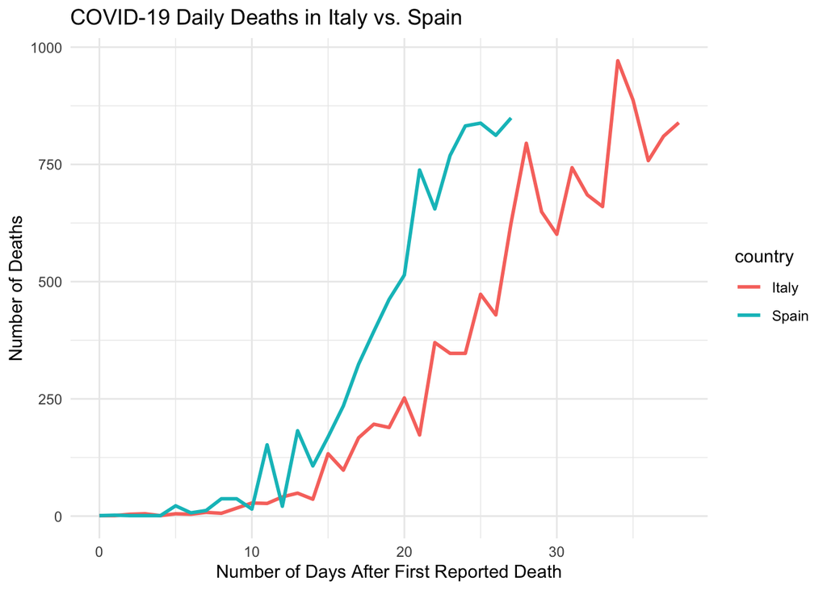

# Problem 3

```
## Estimated Price Elasticity of Demand: -1.619
```

```
## 95% Confidence Interval: -1.765 to -1.448
```

To figure out the price elasticity of demand for milk, I used a model where sales are related to price using a power-law formula: Q = K * P^b, with b being the elasticity. I fit the model to the data, then used bootstrapping by randomly sampling the data 1000 times and running the model each time to get a range of elasticity values. That helped me see the uncertainty around the estimate.